# Presentations

Optimal sensor placement (OPS) in structural health monitoring (SHM)

Thyge Vinther Ludvigsen, s203591

8 Apr, 2026

# Time plan

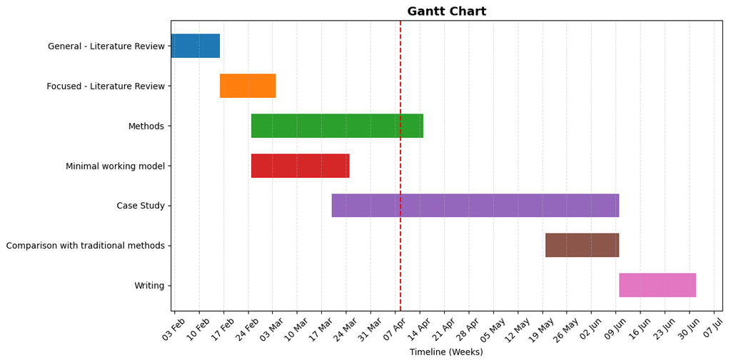

# Big picture

- What is SHM
- What is vibration-based SHM
- Problems in SHM

## What is SHM

Structural Health Monitoring (SHM) - continuous assessment of structures using sensor data

**Levels of SHM**

- Level 1: Damage vs no damage
- Level 2: Localization of damage
- Level 3: Quantification of damage

**Methods of SHM**

Global methods:

- Vibration-based methods
- Optical methods

Local methods:

- Ultrasonic methods
- …

**Advantages of SHM**

- Real-time monitoring
- Early detection of damage
- Reduced maintenance costs
- Improved safety
- Reduced cost to same safety level

## What is Vibration based SHM

**General procedure**

- Gather sensor data
- Operational Modal Analysis (OMA)
- (Calculate Features)
- Compare features with structural states

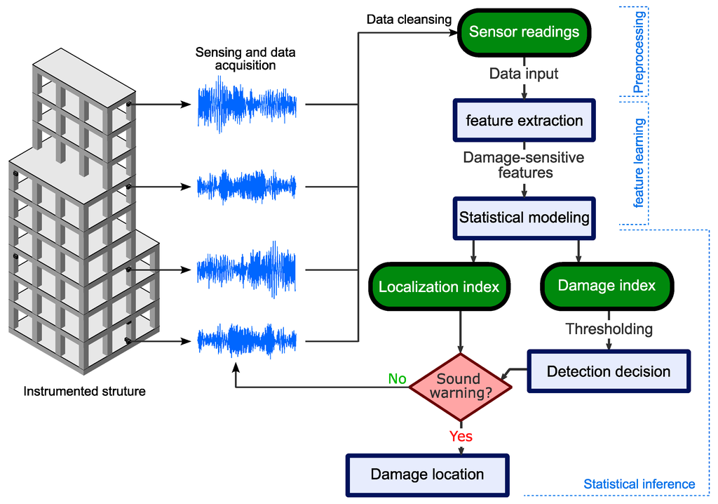

<sup>1</sup>

[^1]: Make my own figure, [link](https://www.mdpi.com/1424-8220/23/6/3290)

## What is Vibration based SHM

**Modal properties**

- Natural frequencies
- Mode shapes
- Damping ratios

## What is Vibration based SHM

**Advantages**

- Modal properties holds global information about the structure
- Few sensors can be used to get estimate global information about the structure
- Ambient excitation can be used to get the dynamic response of the structure.

**Disadvantages**

- The stiffness is highly sensitive to environmental effects, which can lead to false positives.
- Modal properties can be difficult to estimate accurately, especially in the presence of noise and environmental effects.
- There is an large amount of data.

## Problems in SHM

- What is the Optimal Sensor Placement (OSP)?
- Cost-Benefit Quantification?
- Environmental effects?
- Lack of SHM in practice?

# My research focus

Optimal sensor placement (OPS) in structural health monitoring (SHM) whit the use of Bayesian risk.

- General Theory

## Risk

$$R(A) = P(A) \cdot L(A)$$

where:

- $P(A)$ is the probability of an event A occurring.
- $L(A)$ is the utility or loss do to the consequence associated with event A.

## Bayes Risk

$$r(d(x)) = E_{\theta}[E_{X|\theta}[L(\theta, d(x)) | \theta] \cdot f(\theta)] = \int \int L(\theta, d(x)) f(x|\theta) \space dx \space f(\theta) \space d\theta$$

where:

- $r(d(x))$ is the Bayes Risk. <sup>1</sup>
- $d(x)$ is the decision rule that maps the data to a decision.
- $L(\theta, d(x))$ is the loss function that quantifies the loss incurred by making a decision $d(x)$
- $f(x|\theta)$ is the likelihood function that describes the probability of observing the data $x$ given the parameter $\theta$.
[^2]: section 2.3 page 60-65 in the book “The Bayesian Choice From Decision-Theoretic Foundations to Computational Implementations” by Christian P. Robert

## Why use Bayes Risk for OSP?

**Problems in SHM**

- why use Bayes Risk for OSP?
  1. The Bayes framework Is perfect for Updating beliefs about the structural state based on new information.
  2. The Bayes risk is just expected risk for an given sensor configuration.
  3. The Bayes risk can be compared whit not using SHM, which can be used to quantify the benefit of using SHM.

# Methodology

## Big picture - how

**Main Assumptions**

1. How to include stochastic in the model?
   - Sensor noise, Environmental effects, model uncertainty, etc.
2. Set up an noise to feature model for an sensor configuration.
   - …

## Big picture - how

**Main workflow**

1. Set up the FEM model of the structure.
2. Define damage states and sensor configurations.
3. Define the likelihood function, priors, decision rul, and loss function.
4. Estimate the modal properties for each damage state.
5. Evaluate the Bayes risk for an given sensor configuration. whit the use of MCMC sampling or numerical integration.
6. Use an optimization algorithm to find the optimal sensor configuration that minimizes the Bayes risk.

## Bayes Rule

$$\text{Posterior} = \frac{\text{Likelihood} \cdot \text{Prior}}{\text{Evidence}} \Rightarrow f(\theta|x) = \frac{f(x|\theta)f(\theta)}{f(x)}$$

where:

- $f(\theta|x)$ is the posterior distribution of the parameter $\theta$ given the data $x$.
- $f(x|\theta)$ is the likelihood function, which describes the probability of observing the data $x$ given the parameter $\theta$.
- $f(\theta)$ is the prior distribution of the parameter $\theta$, which represents our beliefs about the parameter before observing the data.
- $f(x)$ is the evidence, which can be found by the marginalization of the likelihood and prior.

## Definition

- Structural states: $\theta \in \theta_0 ,..., \theta_k$
- No damage: $H_0 \in \theta_0,..., \theta_n$ (Often: $H_0 = \theta_0$)
- Damage: $H_1 \in \theta_{n+1},..., \theta_k$
- Sensor data: $x(e)$

## Feature Model

- Theory
- Variables

Feature model:
$$y = g(x(e,\theta)) + \epsilon(e)$$

Uncertainty model:
$$\epsilon(e) \sim \mathcal{N}(0, \Sigma), \text{ Multivariate Gaussian noise}$$

where:

- $\Sigma$ is the covariance matrix of the noise

| Symbol | Meaning |
| --- | --- |
| $H$ | No damage $H_0$, Damage $H_1$ |
| $e$ | Sensor configuration |
| $\theta$ | Structural state |
| $x(e)$ | Sensor data |
| $y = g(\theta, x(e, \theta)) + \epsilon(e)$ | Feature vector |
| $g(x(e, \theta))$ | Features Function |
| $\epsilon(e) \sim \mathcal{N}(0, \Sigma)$ | Uncertainty |
| $P(\theta)$, $P(H)$ | Prior probability |
| $f(y \mid \theta)$, $f(y \mid H)$ | Likelihood of measurement |
| $P(\theta \mid y)$ | Posterior probability |
| $L(d(...),\theta\mid C(d(...),\theta))$ | Loss/Utility function |
| $C(d(...),\theta)$ | Cost function |
| $d(...)$ | Decision rule |
| $\Psi(e)$ | Bayes risk |

Reference:

- “Bayesian system identification based on probability logic” (Beck, 2010, p. 825) (pdf)
- “Hierarchical Bayesian model updating for structural identification” (Behmanesh et al., 2015, p. 360) (pdf)

## Likelihood Function

- Theory
- Variables

Likelihood Function (Level 2-3 SHM system):

$$f(y \mid \theta)=
\frac{1}{\sqrt{(2\pi)^n |\Sigma|}}
\exp\left(
-\frac{1}{2}
(y - g(\theta, e))^T
\Sigma^{-1}
(y - g(\theta, e))
\right)$$

Likelihood for the Level 1 SHM system:

$$f(y \mid H_i)= \sum_{\theta \in H_i} f(y \mid \theta) P(\theta \mid H_i)$$

| Symbol | Meaning |
| --- | --- |
| $H$ | No damage $H_0$, Damage $H_1$ |
| $e$ | Sensor configuration |
| $\theta$ | Structural state |
| $x(e)$ | Sensor data |
| $y = g(\theta, x(e, \theta)) + \epsilon(e)$ | Feature vector |
| $g(x(e, \theta))$ | Features Function |
| $\epsilon(e) \sim \mathcal{N}(0, \Sigma)$ | Uncertainty |
| $P(\theta)$, $P(H)$ | Prior probability |
| $f(y \mid \theta)$, $f(y \mid H)$ | Likelihood of measurement |
| $P(\theta \mid y)$ | Posterior probability |
| $L(d(...),\theta\mid C(d(...),\theta))$ | Loss/Utility function |
| $C(d(...),\theta)$ | Cost function |
| $d(...)$ | Decision rule |
| $\Psi(e)$ | Bayes risk |

Reference:

- “Bayesian system identification based on probability logic” (Beck, 2010, p. 825) (pdf)
- “An optimal sensor placement design framework for structural health monitoring using Bayes risk” (Yang et al., 2022, p. 1) (pdf)

## Prior Distribution

- Theory
- Variables

Prior distribution (level 2-3 SHM system):

$$P(\theta)$$

Prior distribution (level 1 SHM system):

$$P(H) = \sum_{\theta \in H} P(\theta)$$

| Symbol | Meaning |
| --- | --- |
| $H$ | No damage $H_0$, Damage $H_1$ |
| $e$ | Sensor configuration |
| $\theta$ | Structural state |
| $x(e)$ | Sensor data |
| $y = g(\theta, x(e, \theta)) + \epsilon(e)$ | Feature vector |
| $g(x(e, \theta))$ | Features Function |
| $\epsilon(e) \sim \mathcal{N}(0, \Sigma)$ | Uncertainty |
| $P(\theta)$, $P(H)$ | Prior probability |
| $f(y \mid \theta)$, $f(y \mid H)$ | Likelihood of measurement |
| $P(\theta \mid y)$ | Posterior probability |
| $L(d(...),\theta\mid C(d(...),\theta))$ | Loss/Utility function |
| $C(d(...),\theta)$ | Cost function |
| $d(...)$ | Decision rule |
| $\Psi(e)$ | Bayes risk |

## Posterior Distribution

- Theory
- Variables

Posterior distribution (level 2-3 SHM system):
$$P(\theta \mid y) =
\frac{f(y \mid \theta) P(\theta)}{f(y)}$$

Posterior distribution (level 1 SHM system):

$$P(H_i \mid y) = \frac{f(y \mid H_i) P(H_i)}{f(y)}$$

| Symbol | Meaning |
| --- | --- |
| $H$ | No damage $H_0$, Damage $H_1$ |
| $e$ | Sensor configuration |
| $\theta$ | Structural state |
| $x(e)$ | Sensor data |
| $y = g(\theta, x(e, \theta)) + \epsilon(e)$ | Feature vector |
| $g(x(e, \theta))$ | Features Function |
| $\epsilon(e) \sim \mathcal{N}(0, \Sigma)$ | Uncertainty |
| $P(\theta)$, $P(H)$ | Prior probability |
| $f(y \mid \theta)$, $f(y \mid H)$ | Likelihood of measurement |
| $P(\theta \mid y)$ | Posterior probability |
| $L(d(...),\theta\mid C(d(...),\theta))$ | Loss/Utility function |
| $C(d(...),\theta)$ | Cost function |
| $d(...)$ | Decision rule |
| $\Psi(e)$ | Bayes risk |

## Decision Rule

- Theory
- Variables

Decision rule - Maximum a posteriori (MAP):
$$d(y) =
\arg\max_{H_i} P(H_i \mid y)$$

Other decision rules:

- Minimum risk decision rule: $d(y) = \arg\max_{d^*} R(\theta, d^*(y))$
  - Much more expensive to compute, but can take into account the cost of making a decision.

| Symbol | Meaning |
| --- | --- |
| $H$ | No damage $H_0$, Damage $H_1$ |
| $e$ | Sensor configuration |
| $\theta$ | Structural state |
| $x(e)$ | Sensor data |
| $y = g(\theta, x(e, \theta)) + \epsilon(e)$ | Feature vector |
| $g(x(e, \theta))$ | Features Function |
| $\epsilon(e) \sim \mathcal{N}(0, \Sigma)$ | Uncertainty |
| $P(\theta)$, $P(H)$ | Prior probability |
| $f(y \mid \theta)$, $f(y \mid H)$ | Likelihood of measurement |
| $P(\theta \mid y)$ | Posterior probability |
| $L(d(...),\theta\mid C(d(...),\theta))$ | Loss/Utility function |
| $C(d(...),\theta)$ | Cost function |
| $d(...)$ | Decision rule |
| $\Psi(e)$ | Bayes risk |

## Loss Function

- Theory
- Variables

Utility / Loss function:
$$L(\theta, d(x)) = C(\theta, d(x))$$

Cost Matrix:
$$C(\theta, d(x)) =
\begin{bmatrix}
C_{00} & C_{01} \\
C_{10} & C_{11}
\end{bmatrix}$$

- $C_{00}$ is the cost of true negative (correctly identifying no damage)
- $C_{01}$ is the cost of false positive (incorrectly identifying damage)
- $C_{10}$ is the cost of false negative (incorrectly identifying no damage)
- $C_{11}$ is the cost of true positive (correctly identifying damage)

| Symbol | Meaning |
| --- | --- |
| $H$ | No damage $H_0$, Damage $H_1$ |
| $e$ | Sensor configuration |
| $\theta$ | Structural state |
| $x(e)$ | Sensor data |
| $y = g(\theta, x(e, \theta)) + \epsilon(e)$ | Feature vector |
| $g(x(e, \theta))$ | Features Function |
| $\epsilon(e) \sim \mathcal{N}(0, \Sigma)$ | Uncertainty |
| $P(\theta)$, $P(H)$ | Prior probability |
| $f(y \mid \theta)$, $f(y \mid H)$ | Likelihood of measurement |
| $P(\theta \mid y)$ | Posterior probability |
| $L(d(...),\theta\mid C(d(...),\theta))$ | Loss/Utility function |
| $C(d(...),\theta)$ | Cost function |
| $d(...)$ | Decision rule |
| $\Psi(e)$ | Bayes risk |

## Bayes Risk

- Theory
- Variables

Bayes Risk:
$$\Psi(e) =
\mathbb{E}_{H, y}\left[
L(d^*(y), H_i)
\right] = \sum_{H_i} P(H_i) \int f(y \mid H_i) L(d^*(y), H_i) dy$$

Optimal Sensor Configuration:
$$e^* = \arg\min_e \Psi(e)$$

| Symbol | Meaning |
| --- | --- |
| $H$ | No damage $H_0$, Damage $H_1$ |
| $e$ | Sensor configuration |
| $\theta$ | Structural state |
| $x(e)$ | Sensor data |
| $y = g(\theta, x(e, \theta)) + \epsilon(e)$ | Feature vector |
| $g(x(e, \theta))$ | Features Function |
| $\epsilon(e) \sim \mathcal{N}(0, \Sigma)$ | Uncertainty |
| $P(\theta)$, $P(H)$ | Prior probability |
| $f(y \mid \theta)$, $f(y \mid H)$ | Likelihood of measurement |
| $P(\theta \mid y)$ | Posterior probability |
| $L(d(...),\theta\mid C(d(...),\theta))$ | Loss/Utility function |
| $C(d(...),\theta)$ | Cost function |
| $d(...)$ | Decision rule |
| $\Psi(e)$ | Bayes risk |

## Most important

- Theory
- Variables

Uncertainty link whit sensor placement:
$$\epsilon(e) = ???$$

Prior probability:
$$P(\theta) = ???$$

Cost matrix:
$$C(\theta, d(x)) = \begin{bmatrix}
C_{00} & C_{01} \\
C_{10} & C_{11}
\end{bmatrix}$$

| Symbol | Meaning |
| --- | --- |
| $H$ | No damage $H_0$, Damage $H_1$ |
| $e$ | Sensor configuration |
| $\theta$ | Structural state |
| $x(e)$ | Sensor data |
| $y = g(\theta, x(e, \theta)) + \epsilon(e)$ | Feature vector |
| $g(x(e, \theta))$ | Features Function |
| $\epsilon(e) \sim \mathcal{N}(0, \Sigma)$ | Uncertainty |
| $P(\theta)$, $P(H)$ | Prior probability |
| $f(y \mid \theta)$, $f(y \mid H)$ | Likelihood of measurement |
| $P(\theta \mid y)$ | Posterior probability |
| $L(d(...),\theta\mid C(d(...),\theta))$ | Loss/Utility function |
| $C(d(...),\theta)$ | Cost function |
| $d(...)$ | Decision rule |
| $\Psi(e)$ | Bayes risk |

## Least Important / Assumptions

- Theory
- Variables

Decision Rule: (Maximum a posteriori (MAP))
$$d(y) =
\arg\max_{H_i} P(H_i \mid y)$$

Computation of the Bayes Risk:

- MCMC sampling
- Numerical integration

Optimization algorithm:
$$???$$

| Symbol | Meaning |
| --- | --- |
| $H$ | No damage $H_0$, Damage $H_1$ |
| $e$ | Sensor configuration |
| $\theta$ | Structural state |
| $x(e)$ | Sensor data |
| $y = g(\theta, x(e, \theta)) + \epsilon(e)$ | Feature vector |
| $g(x(e, \theta))$ | Features Function |
| $\epsilon(e) \sim \mathcal{N}(0, \Sigma)$ | Uncertainty |
| $P(\theta)$, $P(H)$ | Prior probability |
| $f(y \mid \theta)$, $f(y \mid H)$ | Likelihood of measurement |
| $P(\theta \mid y)$ | Posterior probability |
| $L(d(...),\theta\mid C(d(...),\theta))$ | Loss/Utility function |
| $C(d(...),\theta)$ | Cost function |
| $d(...)$ | Decision rule |
| $\Psi(e)$ | Bayes risk |